# Ufo Sightings in the United States

This project analyzes over 80,000 reported UFO sightings across the United States between 1990 and 2013. By visualizing **where** these sightings occurred, we explore how cultural moments, media influence, and historical events may have shaped public perception of unidentified flying objects. Our goal is to understand the broader patterns behind these reports and the societal context in which they emerged.

Why did UFO sightings rise so dramatically from the 1990s into the early 2010s? Was it due to more activity in the skies - or more happening here on Earth?

The initial spike in 1995 sightings may reflect growing cultural obsession with aliens, sparked by The X-Files (1993), the viral Alien Autopsy broadcast, and rising Area 51 conspiracy chatter online.

After a brief dip in 1996, UFO sightings surged between 1997 and 1999, reaching new heights of public interest.

Interestingly, 1997 marked the Phoenix Lights event, one of the most widely reported mass sightings in history. Around the same time, blockbuster films like Independence Day (1996) and Men in Black (1997) dominated pop culture, further legitimizing UFO discourse and likely fueling a wave of new reports.

Sightings rose by over 50% over the next five years - evidence of a general upward trend heading into the early 2000s.

Sightings peaked in 2004, coinciding with the USS Nimitz incident - Navy pilot footage of fast-moving craft that reignited public and military interest in UFOs.

Between 2006 and 2008, sightings rose sharply. Why did this sudden spike occur?

Two widely reported events likely played a role: the 2006 O’Hare Incident, where airport staff saw a disc-shaped object hovering over a United gate, and the Stephenville, Texas sighting in early January 2008, involving dozens of credible witnesses and radar confirmation.

After 2008, sightings dipped slightly through 2010 - perhaps a return to baseline following the media surge around earlier high-profile events?

But from 2010 to 2012, sightings climbed again, reaching new heights and suggesting renewed public engagement with the UFO phenomenon.

The surge in sightings from 2010 to 2012 may have been driven by growing social media use, the viral spread of UFO content, and cultural phenomena like the 2012 Mayan Apocalypse and the launch of Ancient Aliens on TV.

By 2012, public fascination with UFOs had reached a cultural high point - reflected in that year’s record number of reported sightings.

While sightings fluctuated in the years that followed, the buildup to 2012 marked a cultural tipping point, where UFOs moved from fringe curiosity to mainstream conversation.

[figure not shown]

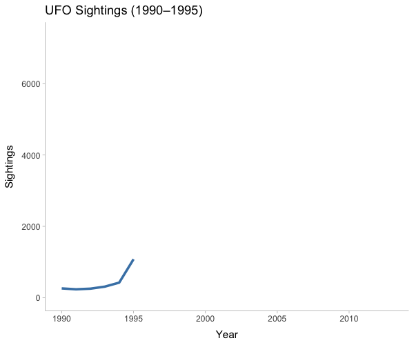

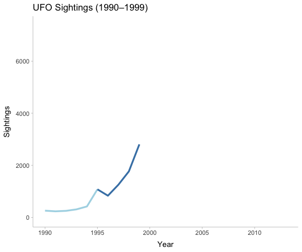

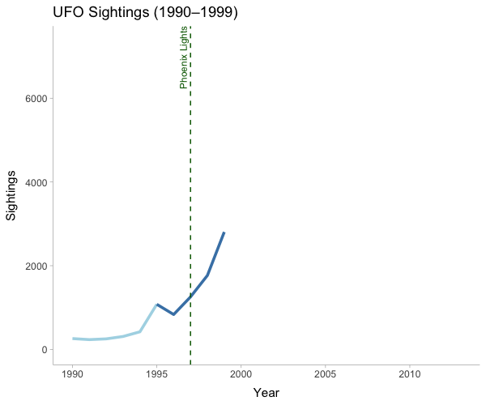

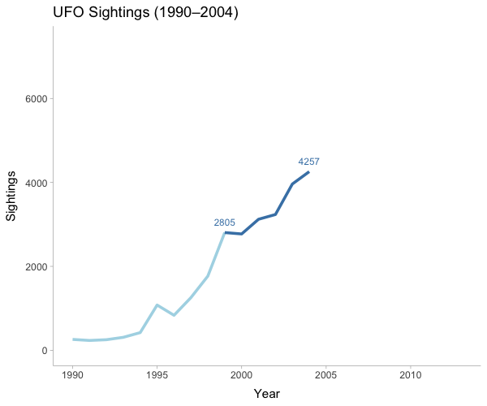

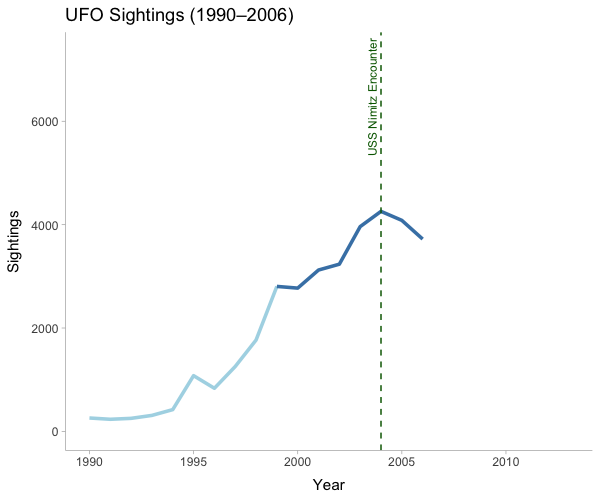

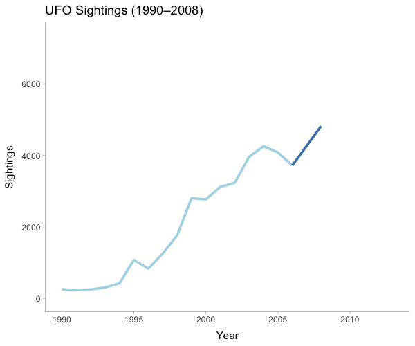

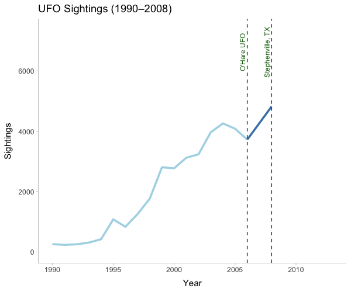

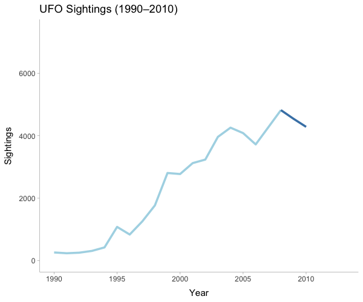

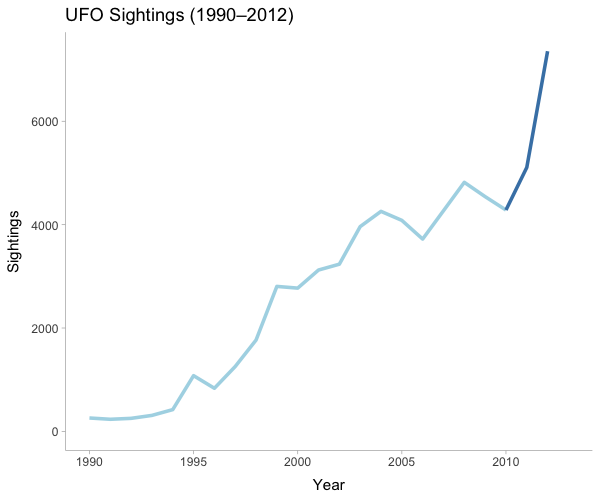

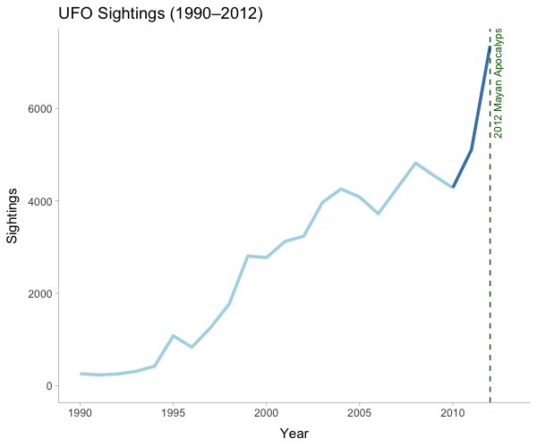

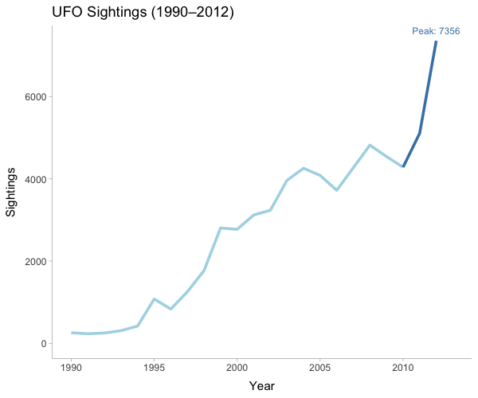

[1 more figures not shown]

**Conclusion:** UFO sighting reports are not merely records of unexplained phenomena - they reflect broader cultural and societal forces. Our visualizations show that spikes in sightings often align with media attention and conspiracies, suggesting that perception plays a critical role in these encounters. By visualizing when and why these reports occurred, we gain insight not just into the data, but into the evolving relationship between society and belief. Ultimately, the story of UFO sightings is as much about us as it is about what’s in the sky.